# Question

Amelia will use 68 feet of fence to build a rectangular enclosure for her dog. Amelia will build the enclosure next to a very long barn, so she’ll only use the fencing for 3 of the sides of the rectangle.

Let $x$ represent the length of fence perpendicular to the barn, and let $y$ represent the length of fence parallel to the barn.

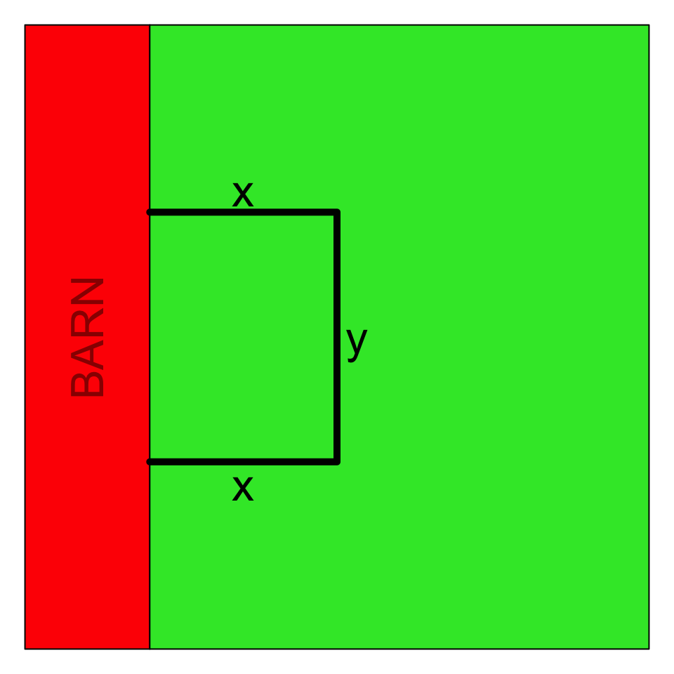

She wants to give her dog as much area as possible. Find the value of $x$ that maximizes the area.

# Solution

The total length of fence is 68 feet. There are 2 sides with lengths of $x$ and one side with a length of $y$.

$$2x+y~=~68$$

Solve for $y$.

$$y~=~68-2x$$

Write an equation for the area. A rectangular area equals the length times the width.

$$A~=~xy$$

Substitute $68-2x$ in place of $y$ to get area in terms of only $x$.

$$A~=~x(68-2x)$$

You can graph $A$ versus $x$ and get a downwards facing parabola.

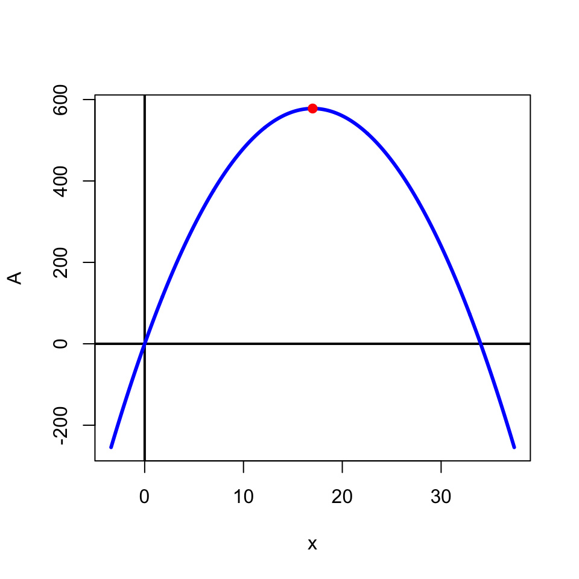

Now, remember the vertex (in this case the maximum) occurs when $x=\frac{-b}{2a}$.

So, the area is maximized when $x=17$ feet and $y=34$ feet.

# Meta-information

extype: num exsolution: 17 exname: optimize_rect_fence_barn